# Summary

This project apply tree-based model to identify fradulent activities.

The data comes from a e-commerce website's transaction data, which contains 151112 number of record. The column information contatin:

- signup_time
- purchase_time
- purchase_value
- source
- browser
- sex
- age
- ip_address
- class (fraud or not )

This project also pulls a third party data source where has ip range information for a specific area. I join these two data by ip address, result shown in cell #12

The metric I use is false negative rate (type 2 error), since I need to pay more attention on transaction not identified as fraud by model but actually is a fraud case.

The data is highly unbalanced: nearly 91% of the data labeled as not fraud while 9% of the data labeled as fraud. So before I move to building models, I apply some resampling methond include **oversampling, undersampling, and SMOTE**.

I also do feature engineer by creating more fields to add more complexity to the data, and I also use **one hot encoding** to guarantee the most accuracy. Fields I create:

- age group large
- age group small
- age group medium
- purchase value large
- purchase value small
- purchase value medium
- weekday or weekend
- morning or evening
- country

The models i used here are **classification tree** and **random forest**. random forest always show better accuracy becuase it is a combination of many trees.

Finally, i print out the feature importace rate graph which tells me which feature can bring larger impact. the top 5 features are the following:

- purchase at night
- sign up on weekend
- purhase on weekend
- sign up at night
- young male age from 20 - 35

The users are more likely to be classified as fraud if sharing the above features.

```python
import pandas as pd
import numpy as np
import matplotlib.pyplot as plt
import seaborn as sns
%matplotlib inline
```

```python
dt = pd.read_csv('Fraud_Data.csv',parse_dates = ['signup_time','purchase_time'])
ip = pd.read_csv('IpAddress_to_Country.csv')
dt = dt.drop(['device_id','user_id'],axis = 1)
dt.info()
dt.head()
```

```
<class 'pandas.core.frame.DataFrame'>
RangeIndex: 151112 entries, 0 to 151111
Data columns (total 9 columns):
signup_time       151112 non-null datetime64[ns]
purchase_time     151112 non-null datetime64[ns]
purchase_value    151112 non-null int64
source            151112 non-null object
browser           151112 non-null object
sex               151112 non-null object
age               151112 non-null int64
ip_address        151112 non-null float64
class             151112 non-null int64
dtypes: datetime64[ns](2), float64(1), int64(3), object(3)
memory usage: 10.4+ MB
```

|  | signup_time | purchase_time | purchase_value | source | browser | sex | age | ip_address | class |
| --- | --- | --- | --- | --- | --- | --- | --- | --- | --- |
| 0 | 2015-02-24 22:55:49 | 2015-04-18 02:47:11 | 34 | SEO | Chrome | M | 39 | 7.327584e+08 | 0 |
| 1 | 2015-06-07 20:39:50 | 2015-06-08 01:38:54 | 16 | Ads | Chrome | F | 53 | 3.503114e+08 | 0 |
| 2 | 2015-01-01 18:52:44 | 2015-01-01 18:52:45 | 15 | SEO | Opera | M | 53 | 2.621474e+09 | 1 |
| 3 | 2015-04-28 21:13:25 | 2015-05-04 13:54:50 | 44 | SEO | Safari | M | 41 | 3.840542e+09 | 0 |
| 4 | 2015-07-21 07:09:52 | 2015-09-09 18:40:53 | 39 | Ads | Safari | M | 45 | 4.155831e+08 | 0 |

```python
ip.info()
ip.head()
```

```
<class 'pandas.core.frame.DataFrame'>
RangeIndex: 138846 entries, 0 to 138845
Data columns (total 3 columns):
lower_bound_ip_address    138846 non-null float64
upper_bound_ip_address    138846 non-null int64
country                   138846 non-null object
dtypes: float64(1), int64(1), object(1)
memory usage: 3.2+ MB
```

|  | lower_bound_ip_address | upper_bound_ip_address | country |
| --- | --- | --- | --- |
| 0 | 16777216.0 | 16777471 | Australia |
| 1 | 16777472.0 | 16777727 | China |
| 2 | 16777728.0 | 16778239 | China |
| 3 | 16778240.0 | 16779263 | Australia |
| 4 | 16779264.0 | 16781311 | China |

# 1. Data Cleaning

```python
dt['country']=np.nan
dt.head()
```

|  | signup_time | purchase_time | purchase_value | source | browser | sex | age | ip_address | class | country |
| --- | --- | --- | --- | --- | --- | --- | --- | --- | --- | --- |
| 0 | 2015-02-24 22:55:49 | 2015-04-18 02:47:11 | 34 | SEO | Chrome | M | 39 | 7.327584e+08 | 0 | NaN |
| 1 | 2015-06-07 20:39:50 | 2015-06-08 01:38:54 | 16 | Ads | Chrome | F | 53 | 3.503114e+08 | 0 | NaN |
| 2 | 2015-01-01 18:52:44 | 2015-01-01 18:52:45 | 15 | SEO | Opera | M | 53 | 2.621474e+09 | 1 | NaN |
| 3 | 2015-04-28 21:13:25 | 2015-05-04 13:54:50 | 44 | SEO | Safari | M | 41 | 3.840542e+09 | 0 | NaN |
| 4 | 2015-07-21 07:09:52 | 2015-09-09 18:40:53 | 39 | Ads | Safari | M | 45 | 4.155831e+08 | 0 | NaN |

```python
#np.where(dt.ip_address=='null',np.nan,dt.ip_address)
#dt
# slicing country and append to dt
'''
ip1=dt.ip_address[5]
ip[(ip.lower_bound_ip_address<=ip1) & (ip.upper_bound_ip_address>=ip1)]
'''
```

```python
country=[]
for i in dt.ip_address:
    temp=ip[(ip.lower_bound_ip_address<=i) & (ip.upper_bound_ip_address>=i)]
    if len(temp)!=0:
        country.append(temp.country.values[0])
        #print(temp.country.values[0])
    else:
        country.append('NA')

# merge new list into dt
dt.country=country
dt.head()
```

|  | signup_time | purchase_time | purchase_value | source | browser | sex | age | ip_address | class | country |
| --- | --- | --- | --- | --- | --- | --- | --- | --- | --- | --- |
| 0 | 2015-02-24 22:55:49 | 2015-04-18 02:47:11 | 34 | SEO | Chrome | M | 39 | 7.327584e+08 | 0 | Japan |
| 1 | 2015-06-07 20:39:50 | 2015-06-08 01:38:54 | 16 | Ads | Chrome | F | 53 | 3.503114e+08 | 0 | United States |
| 2 | 2015-01-01 18:52:44 | 2015-01-01 18:52:45 | 15 | SEO | Opera | M | 53 | 2.621474e+09 | 1 | United States |
| 3 | 2015-04-28 21:13:25 | 2015-05-04 13:54:50 | 44 | SEO | Safari | M | 41 | 3.840542e+09 | 0 | NA |
| 4 | 2015-07-21 07:09:52 | 2015-09-09 18:40:53 | 39 | Ads | Safari | M | 45 | 4.155831e+08 | 0 | United States |

```python
dt=dt.drop('ip_address',axis = 1)
dt.head()
```

|  | signup_time | purchase_time | purchase_value | source | browser | sex | age | class | country |
| --- | --- | --- | --- | --- | --- | --- | --- | --- | --- |
| 0 | 2015-02-24 22:55:49 | 2015-04-18 02:47:11 | 34 | SEO | Chrome | M | 39 | 0 | Japan |
| 1 | 2015-06-07 20:39:50 | 2015-06-08 01:38:54 | 16 | Ads | Chrome | F | 53 | 0 | United States |
| 2 | 2015-01-01 18:52:44 | 2015-01-01 18:52:45 | 15 | SEO | Opera | M | 53 | 1 | United States |
| 3 | 2015-04-28 21:13:25 | 2015-05-04 13:54:50 | 44 | SEO | Safari | M | 41 | 0 | NA |
| 4 | 2015-07-21 07:09:52 | 2015-09-09 18:40:53 | 39 | Ads | Safari | M | 45 | 0 | United States |

```python
def value_threshold(x):
    if x <= 10:
        return 'Small'
    elif x >10 and x<= 20:
        return 'Medium'
    elif x > 20 and x<=50:
        return 'Large'
    else:
        return 'Huge'

a=[]
for i in dt.purchase_value:
        a.append(value_threshold(i))

dt.purchase_value = a
dt.head()
```

|  | signup_time | purchase_time | purchase_value | source | browser | sex | age | class | country |
| --- | --- | --- | --- | --- | --- | --- | --- | --- | --- |
| 0 | 2015-02-24 22:55:49 | 2015-04-18 02:47:11 | Large | SEO | Chrome | M | 39 | 0 | Japan |
| 1 | 2015-06-07 20:39:50 | 2015-06-08 01:38:54 | Medium | Ads | Chrome | F | 53 | 0 | United States |
| 2 | 2015-01-01 18:52:44 | 2015-01-01 18:52:45 | Medium | SEO | Opera | M | 53 | 1 | United States |
| 3 | 2015-04-28 21:13:25 | 2015-05-04 13:54:50 | Large | SEO | Safari | M | 41 | 0 | NA |
| 4 | 2015-07-21 07:09:52 | 2015-09-09 18:40:53 | Large | Ads | Safari | M | 45 | 0 | United States |

```python
def age_threshold(x):
    if x <= 20:
        return 'Teen'
    elif x >20 and x<= 35:
        return 'Young'
    elif x > 35 and x<=50:
        return 'Adult'
    else:
        return 'Senior'

b=[]
for i in dt.age:
        b.append(age_threshold(i))

dt.age = b
dt.head()
```

|  | signup_time | purchase_time | purchase_value | source | browser | sex | age | class | country |
| --- | --- | --- | --- | --- | --- | --- | --- | --- | --- |
| 0 | 2015-02-24 22:55:49 | 2015-04-18 02:47:11 | Large | SEO | Chrome | M | Adult | 0 | Japan |
| 1 | 2015-06-07 20:39:50 | 2015-06-08 01:38:54 | Medium | Ads | Chrome | F | Senior | 0 | United States |
| 2 | 2015-01-01 18:52:44 | 2015-01-01 18:52:45 | Medium | SEO | Opera | M | Senior | 1 | United States |
| 3 | 2015-04-28 21:13:25 | 2015-05-04 13:54:50 | Large | SEO | Safari | M | Adult | 0 | NA |
| 4 | 2015-07-21 07:09:52 | 2015-09-09 18:40:53 | Large | Ads | Safari | M | Adult | 0 | United States |

###### dt Update 1

- Purchase_value
- age

```python
clean1_dt = dt
clean1_dt.head()
```

|  | signup_time | purchase_time | purchase_value | source | browser | sex | age | class | country |
| --- | --- | --- | --- | --- | --- | --- | --- | --- | --- |
| 0 | 2015-02-24 22:55:49 | 2015-04-18 02:47:11 | Large | SEO | Chrome | M | Adult | 0 | Japan |
| 1 | 2015-06-07 20:39:50 | 2015-06-08 01:38:54 | Medium | Ads | Chrome | F | Senior | 0 | United States |
| 2 | 2015-01-01 18:52:44 | 2015-01-01 18:52:45 | Medium | SEO | Opera | M | Senior | 1 | United States |
| 3 | 2015-04-28 21:13:25 | 2015-05-04 13:54:50 | Large | SEO | Safari | M | Adult | 0 | NA |
| 4 | 2015-07-21 07:09:52 | 2015-09-09 18:40:53 | Large | Ads | Safari | M | Adult | 0 | United States |

###### dt Update 2

- get_dummy

```python
value_amount = pd.get_dummies(dt.purchase_value,drop_first=True)
value_amount.head()

sources = pd.get_dummies(dt.source,drop_first=True)
sources.head()

browsers = pd.get_dummies(dt.browser,drop_first=True)
browsers.head()

gender = pd.get_dummies(dt.sex,drop_first=True)
gender.head()

age_group = pd.get_dummies(dt.age,drop_first=True)
age_group.head()

region = pd.get_dummies(dt.country,drop_first=True)
region.head()

dt=pd.concat([dt,value_amount,sources,browsers,gender,age_group,region],axis = 1)
dt.info()
```

```
<class 'pandas.core.frame.DataFrame'>
RangeIndex: 151112 entries, 0 to 151111
Columns: 203 entries, signup_time to Zimbabwe
dtypes: datetime64[ns](2), int64(1), object(6), uint8(194)
memory usage: 38.3+ MB
```

```python
dt.drop(['purchase_value','source','browser','sex','age','country'],axis=1,inplace=True)
dt.info()
dt.head()

clean2_dt=dt
clean2_dt.head()
```

```
<class 'pandas.core.frame.DataFrame'>
RangeIndex: 151112 entries, 0 to 151111
Columns: 197 entries, signup_time to Zimbabwe
dtypes: datetime64[ns](2), int64(1), uint8(194)
memory usage: 31.4 MB
```

|  | signup_time | purchase_time | class | Large | Medium | Small | Direct | SEO | FireFox | IE | ... | United States | Uruguay | Uzbekistan | Vanuatu | Venezuela | Viet Nam | Virgin Islands (U.S.) | Yemen | Zambia | Zimbabwe |
| --- | --- | --- | --- | --- | --- | --- | --- | --- | --- | --- | --- | --- | --- | --- | --- | --- | --- | --- | --- | --- | --- |
| 0 | 2015-02-24 22:55:49 | 2015-04-18 02:47:11 | 0 | 1 | 0 | 0 | 0 | 1 | 0 | 0 | ... | 0 | 0 | 0 | 0 | 0 | 0 | 0 | 0 | 0 | 0 |
| 1 | 2015-06-07 20:39:50 | 2015-06-08 01:38:54 | 0 | 0 | 1 | 0 | 0 | 0 | 0 | 0 | ... | 1 | 0 | 0 | 0 | 0 | 0 | 0 | 0 | 0 | 0 |
| 2 | 2015-01-01 18:52:44 | 2015-01-01 18:52:45 | 1 | 0 | 1 | 0 | 0 | 1 | 0 | 0 | ... | 1 | 0 | 0 | 0 | 0 | 0 | 0 | 0 | 0 | 0 |
| 3 | 2015-04-28 21:13:25 | 2015-05-04 13:54:50 | 0 | 1 | 0 | 0 | 0 | 1 | 0 | 0 | ... | 0 | 0 | 0 | 0 | 0 | 0 | 0 | 0 | 0 | 0 |
| 4 | 2015-07-21 07:09:52 | 2015-09-09 18:40:53 | 0 | 1 | 0 | 0 | 0 | 0 | 0 | 0 | ... | 1 | 0 | 0 | 0 | 0 | 0 | 0 | 0 | 0 | 0 |

5 rows × 197 columns

# dt Update 3

- datetime
- weekday / weekend
- day / night

```python
#import datetime as datetime
#clean2_dt.date1 = clean2_dt['signup_time'].weekday()
clean2_dt.signup_day = clean2_dt.signup_time.apply(lambda x: x.weekday)
clean2_dt.head()
```

```
D:\Anaconda 3\lib\site-packages\ipykernel_launcher.py:3: UserWarning: Pandas doesn't allow columns to be created via a new attribute name - see https://pandas.pydata.org/pandas-docs/stable/indexing.html#attribute-access
  This is separate from the ipykernel package so we can avoid doing imports until
```

|  | signup_time | purchase_time | class | Large | Medium | Small | Direct | SEO | FireFox | IE | ... | United States | Uruguay | Uzbekistan | Vanuatu | Venezuela | Viet Nam | Virgin Islands (U.S.) | Yemen | Zambia | Zimbabwe |
| --- | --- | --- | --- | --- | --- | --- | --- | --- | --- | --- | --- | --- | --- | --- | --- | --- | --- | --- | --- | --- | --- |
| 0 | 2015-02-24 22:55:49 | 2015-04-18 02:47:11 | 0 | 1 | 0 | 0 | 0 | 1 | 0 | 0 | ... | 0 | 0 | 0 | 0 | 0 | 0 | 0 | 0 | 0 | 0 |
| 1 | 2015-06-07 20:39:50 | 2015-06-08 01:38:54 | 0 | 0 | 1 | 0 | 0 | 0 | 0 | 0 | ... | 1 | 0 | 0 | 0 | 0 | 0 | 0 | 0 | 0 | 0 |
| 2 | 2015-01-01 18:52:44 | 2015-01-01 18:52:45 | 1 | 0 | 1 | 0 | 0 | 1 | 0 | 0 | ... | 1 | 0 | 0 | 0 | 0 | 0 | 0 | 0 | 0 | 0 |
| 3 | 2015-04-28 21:13:25 | 2015-05-04 13:54:50 | 0 | 1 | 0 | 0 | 0 | 1 | 0 | 0 | ... | 0 | 0 | 0 | 0 | 0 | 0 | 0 | 0 | 0 | 0 |
| 4 | 2015-07-21 07:09:52 | 2015-09-09 18:40:53 | 0 | 1 | 0 | 0 | 0 | 0 | 0 | 0 | ... | 1 | 0 | 0 | 0 | 0 | 0 | 0 | 0 | 0 | 0 |

5 rows × 197 columns

```python
#a.weekday()
```

```python
signup_dayofweek = []
for i in clean2_dt.signup_time:
    signup_dayofweek.append(i.weekday())

purchase_dayofweek = []
for i in clean2_dt.purchase_time:
    purchase_dayofweek.append(i.weekday())
```

```python
def dayofweek(x):
    if x>=0 and x<=4:
        return 'weekday'
    else:
        return 'weekend'
```

```python
# cleaned day of week for signup & purchase
signup_dow = [ dayofweek(i) for i in signup_dayofweek]
signup_dow

purchase_dow = [dayofweek(i) for i in purchase_dayofweek]
```

```python
# cleand day & night column
signup_day_night=[]
for i in clean2_dt.signup_time:
    if i.hour >8 and i.hour <18:
        signup_day_night.append('morning')
    else:
        signup_day_night.append('night')

signup_day_night

purchase_day_night=[]
for i in clean2_dt.purchase_time:
    if i.hour >8 and i.hour <18:
        purchase_day_night.append('morning')
    else:
        purchase_day_night.append('night')
```

```python
signup_dow = pd.Series(signup_dow)
purchase_dow = pd.Series(purchase_dow)
signup_day_night = pd.Series(signup_day_night)
purchase_day_night = pd.Series(purchase_day_night)
```

```python
clean3_dt = pd.concat([clean2_dt,signup_dow,purchase_dow,signup_day_night,purchase_day_night],axis = 1)
clean3_dt.drop(['signup_time','purchase_time'],axis = 1,inplace=True)
clean3_dt.columns
```

```
Index([                'class',                 'Large',
                      'Medium',                 'Small',
                      'Direct',                   'SEO',
                     'FireFox',                    'IE',
                       'Opera',                'Safari',
       ...
                   'Venezuela',              'Viet Nam',
       'Virgin Islands (U.S.)',                 'Yemen',
                      'Zambia',              'Zimbabwe',
                             0,                       1,
                             2,                       3],
      dtype='object', length=199)
```

```python
clean3_dt = clean3_dt.rename(columns = {0:'signup_dow1',1:'purchase_dow1',2:'signup_day_night1',3:'purchase_day_night1'})
```

```python
clean3_dt.columns
```

```
Index(['class', 'Large', 'Medium', 'Small', 'Direct', 'SEO', 'FireFox', 'IE',
       'Opera', 'Safari',
       ...
       'Venezuela', 'Viet Nam', 'Virgin Islands (U.S.)', 'Yemen', 'Zambia',
       'Zimbabwe', 'signup_dow1', 'purchase_dow1', 'signup_day_night1',
       'purchase_day_night1'],
      dtype='object', length=199)
```

```python
# get dummies
signup_dow2 = pd.get_dummies(clean3_dt.signup_dow1,drop_first=True)

purchase_dow2 = pd.get_dummies(clean3_dt.purchase_dow1,drop_first=True)

signup_day_night2 = pd.get_dummies(clean3_dt.signup_day_night1,drop_first=True)

purchase_day_night2 = pd.get_dummies(clean3_dt.purchase_day_night1,drop_first=True)
```

```python
# rename columns
signup_weekend=signup_dow2.rename(columns = {'weekend': 'signup_weekend'})
purchase_weekend=purchase_dow2.rename(columns = {'weekend': 'purchase_weekend'})

signup_night=signup_day_night2.rename(columns = {'night': 'signup_night'})
purchase_night=purchase_day_night2.rename(columns = {'night': 'purchase_night'})
```

```python
clean3_dt=pd.concat([clean3_dt,signup_weekend,purchase_weekend,signup_night,purchase_night],axis = 1)
data = clean3_dt.drop(['signup_dow1', 'purchase_dow1', 'signup_day_night1',
       'purchase_day_night1'],axis = 1)

data.head()
```

[output not shown]

```python
pwd
```

```
'C:\\Users\\jasmi\\Desktop\\collection of ds\\Identifying Fraudulent Activities\\Fraud'
```

# 2. Models

#### ploting imbalanced data

```python
target_count = data['class'].value_counts()
print('Class 0:', target_count[0])
print('Class 1:', target_count[1])
print('Proportion:', round(target_count[0] / target_count[1], 2), ': 1')

target_count.plot(kind='bar', title='Count (target)')
```

[output not shown]

```
Class 0: 136961
Class 1: 14151
Proportion: 9.68 : 1
```

#### UNDERsampling data

```python
fraud=data[data['class']==1]
not_fraud=data[data['class']!=1]
```

```python
len(fraud)
fraud.head()
```

|  | class | Large | Medium | Small | Direct | SEO | FireFox | IE | Opera | Safari | ... | Venezuela | Viet Nam | Virgin Islands (U.S.) | Yemen | Zambia | Zimbabwe | signup_weekend | purchase_weekend | signup_night | purchase_night |
| --- | --- | --- | --- | --- | --- | --- | --- | --- | --- | --- | --- | --- | --- | --- | --- | --- | --- | --- | --- | --- | --- |
| 2 | 1 | 0 | 1 | 0 | 0 | 1 | 0 | 0 | 1 | 0 | ... | 0 | 0 | 0 | 0 | 0 | 0 | 0 | 0 | 1 | 1 |
| 24 | 1 | 0 | 0 | 0 | 1 | 0 | 0 | 1 | 0 | 0 | ... | 0 | 0 | 0 | 0 | 0 | 0 | 1 | 1 | 1 | 1 |
| 25 | 1 | 1 | 0 | 0 | 0 | 1 | 1 | 0 | 0 | 0 | ... | 0 | 0 | 0 | 0 | 0 | 0 | 1 | 0 | 1 | 1 |
| 29 | 1 | 1 | 0 | 0 | 0 | 1 | 0 | 0 | 0 | 0 | ... | 0 | 0 | 0 | 0 | 0 | 0 | 0 | 0 | 1 | 1 |
| 59 | 1 | 1 | 0 | 0 | 0 | 1 | 0 | 1 | 0 | 0 | ... | 0 | 0 | 0 | 0 | 0 | 0 | 1 | 0 | 1 | 1 |

5 rows × 199 columns

```python
import random
```

```python
resampled_not_fraud = not_fraud.sample(n=len(fraud))
resampled_not_fraud.head()
```

|  | class | Large | Medium | Small | Direct | SEO | FireFox | IE | Opera | Safari | ... | Venezuela | Viet Nam | Virgin Islands (U.S.) | Yemen | Zambia | Zimbabwe | signup_weekend | purchase_weekend | signup_night | purchase_night |
| --- | --- | --- | --- | --- | --- | --- | --- | --- | --- | --- | --- | --- | --- | --- | --- | --- | --- | --- | --- | --- | --- |
| 144192 | 0 | 1 | 0 | 0 | 0 | 1 | 0 | 0 | 0 | 0 | ... | 0 | 0 | 0 | 0 | 0 | 0 | 0 | 1 | 1 | 1 |
| 28900 | 0 | 0 | 0 | 0 | 0 | 1 | 0 | 0 | 0 | 0 | ... | 0 | 0 | 0 | 0 | 0 | 0 | 1 | 0 | 1 | 1 |
| 55716 | 0 | 1 | 0 | 0 | 0 | 1 | 0 | 1 | 0 | 0 | ... | 0 | 0 | 0 | 0 | 0 | 0 | 0 | 0 | 0 | 0 |
| 52480 | 0 | 1 | 0 | 0 | 0 | 1 | 0 | 0 | 0 | 0 | ... | 0 | 0 | 0 | 0 | 0 | 0 | 0 | 1 | 1 | 1 |
| 81350 | 0 | 0 | 1 | 0 | 0 | 0 | 0 | 0 | 0 | 0 | ... | 0 | 0 | 0 | 0 | 0 | 0 | 0 | 1 | 1 | 0 |

5 rows × 199 columns

```python
balanced_data = pd.concat([fraud, resampled_not_fraud],axis = 0)
```

```python
len(balanced_data)
```

```
28302
```

```python
balanced_data.head()
```

|  | class | Large | Medium | Small | Direct | SEO | FireFox | IE | Opera | Safari | ... | Venezuela | Viet Nam | Virgin Islands (U.S.) | Yemen | Zambia | Zimbabwe | signup_weekend | purchase_weekend | signup_night | purchase_night |
| --- | --- | --- | --- | --- | --- | --- | --- | --- | --- | --- | --- | --- | --- | --- | --- | --- | --- | --- | --- | --- | --- |
| 2 | 1 | 0 | 1 | 0 | 0 | 1 | 0 | 0 | 1 | 0 | ... | 0 | 0 | 0 | 0 | 0 | 0 | 0 | 0 | 1 | 1 |
| 24 | 1 | 0 | 0 | 0 | 1 | 0 | 0 | 1 | 0 | 0 | ... | 0 | 0 | 0 | 0 | 0 | 0 | 1 | 1 | 1 | 1 |
| 25 | 1 | 1 | 0 | 0 | 0 | 1 | 1 | 0 | 0 | 0 | ... | 0 | 0 | 0 | 0 | 0 | 0 | 1 | 0 | 1 | 1 |
| 29 | 1 | 1 | 0 | 0 | 0 | 1 | 0 | 0 | 0 | 0 | ... | 0 | 0 | 0 | 0 | 0 | 0 | 0 | 0 | 1 | 1 |
| 59 | 1 | 1 | 0 | 0 | 0 | 1 | 0 | 1 | 0 | 0 | ... | 0 | 0 | 0 | 0 | 0 | 0 | 1 | 0 | 1 | 1 |

5 rows × 199 columns

```python
from sklearn.model_selection import train_test_split

X = balanced_data.drop('class',axis=1)
y=balanced_data['class']

X_train, X_test, y_train, y_test = train_test_split(X, y, test_size=0.2, random_state=101)
```

#### classification tree

```python
from sklearn.tree import DecisionTreeClassifier
dtree = DecisionTreeClassifier()
dtree.fit(X_train,y_train)
pred = dtree.predict(X_test)
```

```python
from sklearn.metrics import classification_report, confusion_matrix
print(confusion_matrix(y_test,pred))
```

```
[[1984  852]
 [ 897 1928]]
```

```python
print(classification_report(y_test,pred))
```

```
              precision    recall  f1-score   support

           0       0.69      0.70      0.69      2836
           1       0.69      0.68      0.69      2825

    accuracy                           0.69      5661
   macro avg       0.69      0.69      0.69      5661
weighted avg       0.69      0.69      0.69      5661
```

```python
from sklearn.metrics import roc_auc_score
roc_auc_score(y_test,pred)
```

```
0.6910273724677659
```

#### random forest

```python
from sklearn.ensemble import RandomForestClassifier
rf = RandomForestClassifier(n_estimators=200)
rf.fit(X_train,y_train)
rfc_pred=rf.predict(X_test)
```

```python
print(confusion_matrix(y_test,rfc_pred))
print(classification_report(y_test,rfc_pred))
```

```
[[2120  716]
 [ 942 1883]]
              precision    recall  f1-score   support

           0       0.69      0.75      0.72      2836
           1       0.72      0.67      0.69      2825

    accuracy                           0.71      5661
   macro avg       0.71      0.71      0.71      5661
weighted avg       0.71      0.71      0.71      5661
```

```python
roc_auc_score(y_test,rfc_pred)
```

```
0.7070402037020856
```

#### SMOTE

```python
X = data.drop('class',axis=1)
y=data['class']

X_train, X_test, y_train, y_test = train_test_split(X, y, test_size=0.2, random_state=101)
```

```python
from imblearn.over_sampling import SMOTE

smote = SMOTE(random_state=1)
X_sm, y_sm = smote.fit_sample(X_train, y_train)
```

```python
rf = RandomForestClassifier(n_estimators=100)
rf.fit(X_sm,y_sm)
rfc_pred1=rf.predict(X_test)
```

```python
print(confusion_matrix(y_test,rfc_pred1))
print(classification_report(y_test,rfc_pred1))
```

```
[[24360  3058]
 [ 1170  1635]]
              precision    recall  f1-score   support

           0       0.95      0.89      0.92     27418
           1       0.35      0.58      0.44      2805

    accuracy                           0.86     30223
   macro avg       0.65      0.74      0.68     30223
weighted avg       0.90      0.86      0.88     30223
```

```python
roc_auc_score(y_test,rfc_pred1)
```

```
0.7356775653450659
```

#### SMOTE+Tomek

```python
from imblearn.combine import SMOTETomek

smt = SMOTETomek(random_state=1)
X_smt, y_smt = smt.fit_sample(X_train, y_train)
```

```python
# random forest
rf = RandomForestClassifier(n_estimators=100)
rf.fit(X_smt, y_smt)
rfc_pred2=rf.predict(X_test)
```

```python
print(confusion_matrix(y_test,rfc_pred2))
print(classification_report(y_test,rfc_pred2))
print(roc_auc_score(y_test,rfc_pred2))
```

```
[[24331  3087]
 [ 1167  1638]]
              precision    recall  f1-score   support

           0       0.95      0.89      0.92     27418
           1       0.35      0.58      0.44      2805

    accuracy                           0.86     30223
   macro avg       0.65      0.74      0.68     30223
weighted avg       0.90      0.86      0.87     30223

0.7356834750425479
```

#### Graph base on feature importance rate descending

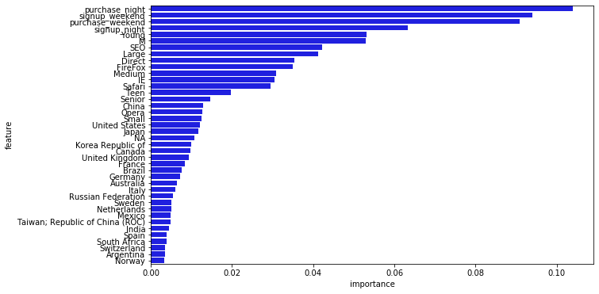

```python
# Extract the feature importances and zip it with the columns into a dataframe# Extrac
importances = rf.feature_importances_
features = pd.DataFrame({'feature': X_test.columns, 'importance': importances})
features.sort_values(by='importance', ascending=False, inplace=True)

# Display a horizontal barplot with the feature importances
plt.figure(figsize=(10,6))
sns.barplot(x=features['importance'], y=features['feature'][:40], color='blue', orient='h')
```